# Predicting the Success of NFL Draftees

## Holland Emery and Ryan Berger

# Introduction

We wanted to see how the draft position of players in the NFL relates to their succesfulnes in the NFl. If you are drafted first are you really the best player drafted that year. The first thing that we had to do was collect stats about players in the NFL and draft information. Then we calculated the succesfulness of every player by year based on their stats. We then standardized the scores based on position, since the different positions have very different successes, the max kicker score is close to 1200 while the max QB score is 140. We then averaged all of the seasons of each player and added the offset for Pro-Bowl selections to create a standardized success for each player. The NFL is one of the largest entertainment industries in the United States earning over $8 Billion in revenue in the 2018 season. Teams are always trying to get the most out of draft picks and other resources so understanding the draft and the potential success of draft picks is extremely important to a teams success. Data Science is important to coaches and other executives of a team to maximize the impact that they have on the league. If you are unfamilier with the structure of the nfl draft and the positions of player here are some useful links to provide important information about the nfl.

[How the NFL Draft Works](https://www.sportingnews.com/us/nfl/news/how-does-the-nfl-draft-work-rules-rounds-eligibility-and-more/o431yshp0l431e7543pcrzpg1)

[Official NFL Website](https://www.nfl.com/)

[Information about the NFL](https://en.wikipedia.org/wiki/National_Football_League)

[Game Information](https://en.wikipedia.org/wiki/American_football)

```python
import pandas as pd
import sqlite3
import seaborn as sns
import sklearn
from sklearn import linear_model
import numpy as np
import matplotlib.pyplot as plt
import statsmodels.formula.api as sm
import warnings
warnings.filterwarnings('ignore')
```

# Collecting Data

To get started we first had to get a list of every player drafted in the nfl, we chose to cut the lower bound for the year at 1970 since before then the data collected is inconsistent at best. To do this we scraped the draft information from the NFL official website. The NFL website seperates drafts by year so we were able to collect only the data that we wanted to work with in an organized manner. Once we had every player drafted we then had to collect the stats for each individual player, we were able to use a large database of stats collected from [kaggle](https://www.kaggle.com/kendallgillies/nflstatistics). The statistical data was stored in csv files which we then converted to sql tables for ease of use. The stats collected included individual statistics for recieving, passing, rushing, kicking, and defensive plays broken apart by year and player. Once we had this data we had every player drafted and their corresponding carrer statistics. There isn't code for player statistic because the information was already neatly packaged in csv files. We also needed to collect the number of pro-bowls each player went to since that is an important indicator of the success of a player.

# Code for scraping draft information

Since we stored all important data in sql databases most of the code involved in data collection and cleaning will be shown in markdown due to the fact that the files are large the code only needs to be run once to structure the data in a usable manner.

from bs4 import BeautifulSoup as bs  
import pandas as pd  
import sqlite3  
import requests  
from os import path  
import re  
import urllib

def scrape(url, year):

```
g = requests.get(url)
page = bs(g.content)
table = page.findAll('table')
draft = pd.read_html(str(table))
rounds = 1
returned = pd.DataFrame(columns = ['pick', 'team', 'player', 'position', 'college', 'year', 'round'])
for i in draft:
    result = i
    result.columns = ['pick', 'team', 'player', 'position', 'college']
    result['year'] = year
    result['round'] = rounds
    rounds += 1
    returned = returned.append(result)
return returned
```

## Pro-Bowl scraper

from bs4 import BeautifulSoup as bs  
import pandas as pd  
import sqlite3  
import requests  
from os import path  
import re  
import urllib

def scrape(url):

[output not shown]

if **name** == "**main**":  
drafts = pd.DataFrame()  
for year in range(1970,2017):  
d = scrape('https://www.pro-football-reference.com/years/'+str(year)+'/probowl.htm')  
drafts = drafts.append(d)  
drafts = drafts.reset_index()  
temp = drafts['Player']  
count = pd.DataFrame()  
players = {}  
for i in temp:  
i = i.replace('%','').replace('+','')  
if i in players:  
players[i] += 1  
else:  
players[i] = 1  
results = pd.DataFrame(list(players.items()))  
results.columns= ['Name','Count']  
results['Name'] = results.apply(lambda x: x['Name'].split(' ')[1]+", "+x['Name'].split(' ')[0], axis=1)  
conn = sqlite3.connect('Success.sqlite')  
results.to_sql('ProBowl', con=conn)

# Working with Data

After looking at the data we collected we realized that a majority of players were missing the position they played. This posed a problem since the position a player plays is important in the calculation of their success. to solve this we found a website that contains every player that has every played that has played in the NFL and their corresponding position. This data was scraped in a way that is similar to the draft information. Some players have nicknames that are more commonly used then their given names ie Mike and Michael so we created two tables of names and positions one with the given name and one with the last name and first two initials of their first name. We then determined which statistics are relavent for a player given whether they were an offensive, defensive, or special teams player.

from bs4 import BeautifulSoup as bs  
import pandas as pd  
import sqlite3  
import requests  
from os import path  
import re  
import string  
import urllib

def scrape(url):  
g = requests.get(url)  
page = bs(g.content)  
table = page.find(id='div_players')  
lines = table.findAll('p')  
players = pd.DataFrame(columns=['Name', 'Position', 'Start', 'End'])  
for i in lines:  
t=re.search('(.\n?)', str(i))  
pos = t.group(0).replace('\n','').replace('(','').replace(')','')  
n=re.search('\">.</a>',str(i)).group(0).replace('\">','').replace('</a>','')  
temp = n.split(' ')  
n = temp[1]+', '+temp[0][:2]  
s=re.search('\d\d\d\d-', str(i)).group(0).replace('-','')  
e=re.search('-\d\d\d\d',str(i)).group(0).replace('-','')  
temp = pd.DataFrame({'Name':[n],'Position':[pos], 'Start':[s], 'End':[e]})  
players = players.append(temp)  
return players  
if **name** == "**main**":  
positions = pd.DataFrame()  
for i in list(string.ascii_uppercase):  
pos = scrape("https://www.pro-football-reference.com/players/"+i+"/")  
positions = positions.append(pos)  
positions = positions.reset_index()  
conn = sqlite3.connect('Success.sqlite')  
positions.to_sql('PositionsFirst', con=conn)

# Combining data and Measuring Success

Once we determied which statistics were relevant based on what kind of player you are we were able to calculate the success of a player based on the stats that are important to that player. So this mean for offensive play makers we looked at their receiving yards, rushing yards, touchdowns, and turnovers. The code for calculating success shown below is the same as the code we ran except we are not writing to an sql database.

## Code for calculating success for quarterbacks

```python
file = "Stats.sqlite"
conn = sqlite3.connect(file)
conn2 = sqlite3.connect("Success.sqlite")
query = """SELECT * FROM Career_Stats_Passing WHERE Year > 1969"""
query2 = """SELECT "Player Id", "Year", "Rushing Yards Per Game", "Rushing TDs" FROM Career_Stats_Rushing WHERE Year > 1969"""
query3 = """SELECT "Player ID", "Year", "Fumbles Lost" FROM Career_Stats_Fumbles WHERE Year > 1969"""
qbs = pd.read_sql(query, conn)
run = pd.read_sql(query2, conn)
lost = pd.read_sql(query3, conn)
qbs = pd.merge(qbs, run, how='left', on=['Player Id', 'Year'])
qbs = pd.merge(qbs, lost, how='left', on=['Player Id', 'Year'])
qbs = qbs.replace('--', '0')
qbs = qbs.fillna(0)
qbs['Success'] = qbs.apply(lambda x: float(x['Passer Rating']) + (0.25*float(x['Rushing Yards Per Game']))
    + (0 if float(x['Games Played'])==0 else (6*float(x['Rushing TDs'])/float(x['Games Played']))), axis=1)
qbs['Success'] = qbs.apply(lambda x: x['Success'] - (6*float(x['Fumbles Lost'])), axis=1)
qbs['Success'] = qbs.apply(lambda x: x['Success'] if float(x['Passes Attempted'])>30 and float(x['Games Played']>3) else 0, axis=1)
success = qbs[['Player Id','Name','Year','Position','Team','Success']].copy()
#success.to_sql('QuarterBacks', con=conn2)
success.head()
```

|  | Player Id | Name | Year | Position | Team | Success |
| --- | --- | --- | --- | --- | --- | --- |
| 0 | billdemory/2512778 | Demory, Bill | 1974 | 0 | New York Jets | 0.000 |
| 1 | billdemory/2512778 | Demory, Bill | 1973 | 0 | New York Jets | 22.150 |
| 2 | tomsavage/2543640 | Savage, Tom | 2016 | QB | Houston Texans | 0.000 |
| 3 | tomsavage/2543640 | Savage, Tom | 2014 | QB | Houston Texans | 0.000 |
| 4 | tommymaddox/2501842 | Maddox, Tommy | 2005 | 0 | Pittsburgh Steelers | 41.325 |

## Code for calculating success for offensive players

```python
sqlite_file = "Stats.sqlite"
conn = sqlite3.connect(sqlite_file)
query = """SELECT * FROM Career_Stats_Rushing WHERE Year > 1969"""
query2 = """SELECT * FROM Career_Stats_Receiving WHERE Year > 1969"""
query3 = """SELECT * FROM Career_Stats_Kick_Return WHERE Year > 1969"""
query4 = """SELECT * FROM Career_Stats_Punt_Return Where Year > 1969"""
punt_stats = pd.read_sql(query4,conn)
kick_stats = pd.read_sql(query3,conn)
rushing_stats = pd.read_sql(query,conn)
receiving_stats = pd.read_sql(query2,conn)
combined_stats = pd.merge(rushing_stats,
                          receiving_stats,
                          left_on=["Player Id","Year","Name","Team"],
                          right_on=["Player Id","Year","Name","Team"],
                          how="outer"
                         )
combined_stats = combined_stats.replace("--",0)
combined_stats = combined_stats.fillna(0)
combined_stats["Total Fumbles"] = combined_stats.apply(lambda x: float(x["Fumbles_x"]) + float(x["Fumbles_y"]),axis=1)
combined_stats2 = pd.merge(combined_stats,
                          punt_stats,
                          left_on=["Player Id","Year","Name","Team"],
                          right_on=["Player Id","Year","Name","Team"],
                          how="outer"
                         )
combined_stats2 = combined_stats2.replace("--",0)
combined_stats2 = combined_stats2.fillna(0)
combined_stats2["Total Fumbles"] = combined_stats2.apply(lambda x: float(x["Total Fumbles"]) + float(x["Fumbles"]),axis=1)
combined_stats2=combined_stats2.drop(['Fumbles', 'Fumbles_x', 'Fumbles_y'], axis=1)
combined_stats3 = pd.merge(combined_stats2,
                          kick_stats,
                          left_on=["Player Id","Year","Name","Team"],
                          right_on=["Player Id","Year","Name","Team"],
                          how="outer"
                         )
combined_stats3 = combined_stats3.replace("--",0)
combined_stats3 = combined_stats3.fillna(0)
combined_stats3["Total Fumbles"] = combined_stats3.apply(lambda x: float(x["Total Fumbles"]) + float(x["Fumbles"]),axis=1)
combined_stats3 = combined_stats3.drop(["Fumbles"],axis=1)
combined_stats3["Total TDs"] = combined_stats3.apply(lambda x: float(x["Receiving TDs"]) + float(x["Rushing TDs"]) + float(x["Returns for TDs_x"]) + float(x["Returns for TDs_y"]),axis=1)
combined_stats3["Total Yards Per Return"] = combined_stats3.apply(lambda x: (float(x["Yards Per Return_x"]) + float(x["Yards Per Return_y"]))/2,axis=1)
combined_stats3["Total Yards"] = combined_stats3.apply(lambda x: float(x["Rushing Yards Per Game"]) + float(x["Yards Per Game"]),axis=1)
combined_stats3["Games Played_x"]=combined_stats3["Games Played_x"].astype("float")
combined_stats3["Yards Per Carry"]=combined_stats3.apply(lambda x: 0 if float(x["Rushing Attempts"])<10 else float(x["Yards Per Carry"]),axis=1)
combined_stats3["Success"] = combined_stats3.apply(lambda x:float(x["Total Yards"])*.1+float(x["Total TDs"])*.4+float(x["Total Yards Per Return"])*.2-float(x["Total Fumbles"])*.75,axis=1)
#print(combined_stats3["Success"].max())
conn2 = sqlite3.connect("Success.sqlite")
success = combined_stats3[["Player Id","Name","Year","Team","Success"]]
#success.to_sql("Offense",con=conn2)
success.head()
```

|  | Player Id | Name | Year | Team | Success |
| --- | --- | --- | --- | --- | --- |
| 0 | bobbyfowler/2514295 | Fowler, Bobby | 1985 | New Orleans Saints | 2.42 |
| 1 | quinnjohnson/79593 | Johnson, Quinn | 2013 | Tennessee Titans | 0.00 |
| 2 | quinnjohnson/79593 | Johnson, Quinn | 2012 | Tennessee Titans | 0.28 |
| 3 | quinnjohnson/79593 | Johnson, Quinn | 2011 | Tennessee Titans | 0.75 |
| 4 | quinnjohnson/79593 | Johnson, Quinn | 2011 | Denver Broncos | 0.00 |

## Code for calculating success for Defensive players

```python
sqlite_file = "Stats.sqlite"
conn = sqlite3.connect(sqlite_file)
query = """SELECT * FROM Career_Stats_Defensive WHERE Year > 1969"""
defense_stats = pd.read_sql(query,conn)
query = """SELECT "Player Id","Year", "Forced Fumbles", "Fumble Return TDs" FROM Career_Stats_Fumbles WHERE Year > 1969"""
fumble_stats = pd.read_sql(query,conn)
combined_stats = pd.merge(defense_stats,
                          fumble_stats,
                          left_on=["Player Id","Year"],
                          right_on=["Player Id","Year"],
                          how="left"
                         )
#print(combined_stats.columns)
combined_stats = combined_stats.replace("--",0)
combined_stats = combined_stats.fillna(0)
combined_stats["success"] = combined_stats.apply(lambda x: 0 if x["Games Played"]==0 else (float(x["Assisted Tackles"])*1+float(x["Solo Tackles"])*2+float(x["Sacks"])*3+float(x["Safties"])*6+float(x["Ints"])*5.25+float(x["Forced Fumbles"])*5.25+float(x["Fumble Return TDs"])*31.5+float(x["Ints for TDs"])*31.5)/float(x["Games Played"]),axis=1)
#(combined_stats["Assisted Tackles"].astype('float')*1+combined_stats["Solo Tackles"].astype('float')*2+combined_stats["Sacks"].astype('float')*3+combined_stats["Safties"].astype('float')*6+combined_stats["Ints"].astype('float')*5.25+combined_stats["Forced Fumbles"].astype('float')*5.25+combined_stats["Fumble Return TDs"].astype('float')*31.5+combined_stats["Ints for TDs"].astype('float')*31.5)/combined_stats["Games Played"].astype('float')
#combined_stats["success"] = combined_stats["Assisted Tackles"].astype('float')+combined_stats["Solo Tackles"].astype('float')*2
conn2 = sqlite3.connect("Success.sqlite")
success = combined_stats[['Player Id','Name','Year','Position','Team','success']]
#success.to_sql('Defense',con=conn2)
success.head()
```

|  | Player Id | Name | Year | Position | Team | success |
| --- | --- | --- | --- | --- | --- | --- |
| 0 | quinnjohnson/79593 | Johnson, Quinn | 2013 | 0 | Tennessee Titans | 0.000000 |
| 1 | quinnjohnson/79593 | Johnson, Quinn | 2012 | 0 | Tennessee Titans | 0.125000 |
| 2 | quinnjohnson/79593 | Johnson, Quinn | 2011 | 0 | Tennessee Titans | 0.000000 |
| 3 | quinnjohnson/79593 | Johnson, Quinn | 2011 | 0 | Denver Broncos | 0.000000 |
| 4 | quinnjohnson/79593 | Johnson, Quinn | 2010 | 0 | Green Bay Packers | 0.727273 |

## Code for calculating success for Kickers

```python
file = "Stats.sqlite"
conn = sqlite3.connect(file)
conn2 = sqlite3.connect("Success.sqlite")
query = "SELECT * FROM Career_Stats_Field_Goal_Kickers WHERE Year > 1969"
query2 = """Select "Player Id", "Year", "Out of Bounds Kickoffs", "Kickoffs", "Kickoff Yards" FROM Career_Stats_Kickoff WHERE Year > 1969"""
query3 = """SELECT "Player Id", "Year", "Net Punting Average", "Punts", "Punts Inside 20 Yard Line" FROM Career_Stats_Punting WHERE Year > 1969"""
fg = pd.read_sql(query, conn)
punt = pd.read_sql(query2, conn)
kick = pd.read_sql(query3, conn)
fg = pd.merge(fg, punt, left_on=['Player Id', 'Year'], right_on=['Player Id', 'Year'], how='left')
fg = pd.merge(fg, kick, left_on=['Player Id', 'Year'], right_on=['Player Id', 'Year'], how='left')
fg = fg.replace('--', '0')
fg = fg.fillna('0')
fg['Success'] = fg.apply(lambda x: float(x['Percentage of Extra Points Made'])+ (0 if int(x['FGs Attempted'])<16 else ((float(x['FG Percentage 20-29 Yards'])*1.5)+(float(x['FG Percentage 30-39 Yards'])*2)+(float(x['FG Percentage 40-49 Yards'])*2.5)+(float(x['FG Percentage 50+ Yards']))*3)), axis=1)
fg['Success'] = fg.apply(lambda x: x['Success'] + (.025*float(x['Kickoff Yards'].replace(',','')) * (0 if x['Kickoffs']=='0' else (1- (float(x['Out of Bounds Kickoffs'])/float(x['Kickoffs']))) )), axis=1)
fg['Success'] = fg.apply(lambda x: x['Success'] + (float(x['Net Punting Average']) * (0 if x['Punts']=='0' else ((float(x['Punts Inside 20 Yard Line'])/float(x['Punts']))) )), axis=1)
success = fg[['Player Id','Name','Year','Position','Team','Success']].copy()
#success.to_sql('Kickers', con=conn2)
success.head()
```

|  | Player Id | Name | Year | Position | Team | Success |
| --- | --- | --- | --- | --- | --- | --- |
| 0 | jeffhall/2500970 | Hall, Jeff | 2000 | 0 | St. Louis Rams | 124.3 |
| 1 | charliegogolak/2514998 | Gogolak, Charlie | 1972 | 0 | New England Patriots | 100.0 |
| 2 | charliegogolak/2514998 | Gogolak, Charlie | 1971 | 0 | New England Patriots | 100.0 |
| 3 | charliegogolak/2514998 | Gogolak, Charlie | 1970 | 0 | Boston Patriots | 100.0 |
| 4 | sebastianjanikowski/2504257 | Janikowski, Sebastian | 2016 | K | Oakland Raiders | 925.4 |

### Entity Resolution

Since the position for each player was not consistent throughout the data collected we had to perform entity resolution in order the create workable data. We used the postition tables created to match each player to their position. We did this by first checking to see if their full given name was present in both the tables and if it was not we then checked their last name and first two initials. If neither was present we dropped that player, we did this after we calculated success since the position does not matter when calculating overall success all that matters is the statistics, the defensive players with offensive stats were later dropped from the offensive results. however we did need positions when we wanted to standardize success over each position.

## Quarterback Entity Resolution

```python
sqlite_file = "Success.sqlite"
conn = sqlite3.connect(sqlite_file)
offenseQuery = """SELECT * FROM QuarterBacks"""
offense = pd.read_sql(offenseQuery,conn)
positionQuery = """SELECT * FROM Positions"""
position = pd.read_sql(positionQuery,conn)
c = conn.cursor()
for i in range(len(offense)):
    temp = offense.at[i,"Name"]
    pos = c.execute("""SELECT "Position" from Positions WHERE "Name" LIKE ?""",(temp,))
    test = pos.fetchone()
    if test == None:
        temp2 = temp.split(", ")
        temp3 = temp2[0]+", "+temp2[1][:2]
        pos2 = c.execute("""SELECT "Position" from PositionsFirst WHERE "Name" LIKE ?""",(temp3,))
        offense.at[i,"Position"] = pos2.fetchone()
        #print(temp)
    else:
        offense.at[i,"Position"] = test
    #print(pos.fetchone())
    #print(type(pos.fetchone()))
offense = offense.mask(offense.eq('None')).dropna()
offense["Position"] = offense.apply(lambda x: "QB",axis=1)
#offense.to_sql("QB Position",con=conn)
offense.head()
```

|  | index | Player Id | Name | Year | Position | Team | Success |
| --- | --- | --- | --- | --- | --- | --- | --- |
| 0 | 0 | billdemory/2512778 | Demory, Bill | 1974 | QB | New York Jets | 0.000 |
| 1 | 1 | billdemory/2512778 | Demory, Bill | 1973 | QB | New York Jets | 22.150 |
| 2 | 2 | tomsavage/2543640 | Savage, Tom | 2016 | QB | Houston Texans | 0.000 |
| 3 | 3 | tomsavage/2543640 | Savage, Tom | 2014 | QB | Houston Texans | 0.000 |
| 4 | 4 | tommymaddox/2501842 | Maddox, Tommy | 2005 | QB | Pittsburgh Steelers | 41.325 |

## Kickers Entity Resolution

```python
sqlite_file = "Success.sqlite"
conn = sqlite3.connect(sqlite_file)
offenseQuery = """SELECT * FROM Kickers"""
offense = pd.read_sql(offenseQuery,conn)
positionQuery = """SELECT * FROM Positions"""
position = pd.read_sql(positionQuery,conn)
c = conn.cursor()
for i in range(len(offense)):
    temp = offense.at[i,"Name"]
    pos = c.execute("""SELECT "Position" from Positions WHERE "Name" LIKE ?""",(temp,))
    test = pos.fetchone()
    if test == None:
        temp2 = temp.split(", ")
        temp3 = temp2[0]+", "+temp2[1][:2]
        pos2 = c.execute("""SELECT "Position" from PositionsFirst WHERE "Name" LIKE ?""",(temp3,))
        offense.at[i,"Position"] = pos2.fetchone()
        #print(temp)
    else:
        offense.at[i,"Position"] = test
    #print(pos.fetchone())
    #print(type(pos.fetchone()))
offense = offense.mask(offense.eq('None')).dropna()
offense["Position"] = offense.apply(lambda x: x["Position"][0],axis=1)
#offense.to_sql("Kickers Position",con=conn)
offense.head()
```

|  | index | Player Id | Name | Year | Position | Team | Success |
| --- | --- | --- | --- | --- | --- | --- | --- |
| 0 | 0 | jeffhall/2500970 | Hall, Jeff | 2000 | K | St. Louis Rams | 124.3 |
| 1 | 1 | charliegogolak/2514998 | Gogolak, Charlie | 1972 | K | New England Patriots | 100.0 |
| 2 | 2 | charliegogolak/2514998 | Gogolak, Charlie | 1971 | K | New England Patriots | 100.0 |
| 3 | 3 | charliegogolak/2514998 | Gogolak, Charlie | 1970 | K | Boston Patriots | 100.0 |
| 4 | 4 | sebastianjanikowski/2504257 | Janikowski, Sebastian | 2016 | K | Oakland Raiders | 925.4 |

## Offense Entity Resolution

```python
sqlite_file = "Success.sqlite"
conn = sqlite3.connect(sqlite_file)
offenseQuery = """SELECT * FROM Offense"""
offense = pd.read_sql(offenseQuery,conn)
positionQuery = """SELECT * FROM Positions"""
position = pd.read_sql(positionQuery,conn)
c = conn.cursor()
for i in range(len(offense)):
    temp = offense.at[i,"Name"]
    pos = c.execute("""SELECT "Position" from Positions WHERE "Name" LIKE ?""",(temp,))
    test = pos.fetchone()
    if test == None:
        temp2 = temp.split(", ")
        temp3 = temp2[0]+", "+temp2[1][:2]
        pos2 = c.execute("""SELECT "Position" from PositionsFirst WHERE "Name" LIKE ?""",(temp3,))
        offense.at[i,"Position"] = pos2.fetchone()
        #print(temp)
    else:
        offense.at[i,"Position"] = test
    #print(pos.fetchone())
    #print(type(pos.fetchone()))
offense = offense.mask(offense.eq('None')).dropna()
offense["Position"] = offense.apply(lambda x: x["Position"][0],axis=1)
#offense.to_sql("Offense Position",con=conn)
offense.head()
```

|  | index | Player Id | Name | Year | Team | Success | Position |
| --- | --- | --- | --- | --- | --- | --- | --- |
| 0 | 0 | bobbyfowler/2514295 | Fowler, Bobby | 1985 | New Orleans Saints | 2.42 | F |
| 1 | 1 | quinnjohnson/79593 | Johnson, Quinn | 2013 | Tennessee Titans | 0.00 | RB |
| 2 | 2 | quinnjohnson/79593 | Johnson, Quinn | 2012 | Tennessee Titans | 0.28 | RB |
| 3 | 3 | quinnjohnson/79593 | Johnson, Quinn | 2011 | Tennessee Titans | 0.75 | RB |
| 4 | 4 | quinnjohnson/79593 | Johnson, Quinn | 2011 | Denver Broncos | 0.00 | RB |

## Defensive Entity Resolution

```python
sqlite_file = "Success.sqlite"
conn = sqlite3.connect(sqlite_file)
offenseQuery = """SELECT * FROM Defense"""
offense = pd.read_sql(offenseQuery,conn)
positionQuery = """SELECT * FROM Positions"""
position = pd.read_sql(positionQuery,conn)
c = conn.cursor()
for i in range(len(offense)):
    temp = offense.at[i,"Name"]
    pos = c.execute("""SELECT "Position" from Positions WHERE "Name" LIKE ?""",(temp,))
    test = pos.fetchone()
    if test == None:
        temp2 = temp.split(", ")
        temp3 = temp2[0]+", "+temp2[1][:2]
        pos2 = c.execute("""SELECT "Position" from PositionsFirst WHERE "Name" LIKE ?""",(temp3,))
        offense.at[i,"Position"] = pos2.fetchone()
        #print(temp)
    else:
        offense.at[i,"Position"] = test
    #print(pos.fetchone())
    #print(type(pos.fetchone()))
offense = offense.mask(offense.eq('None')).dropna()
offense["Position"] = offense.apply(lambda x: x["Position"][0],axis=1)
offense.head()
#offense.to_sql("Defense Position",con=conn)
```

|  | index | Player Id | Name | Year | Position | Team | success |
| --- | --- | --- | --- | --- | --- | --- | --- |
| 0 | 0 | quinnjohnson/79593 | Johnson, Quinn | 2013 | RB | Tennessee Titans | 0.000000 |
| 1 | 1 | quinnjohnson/79593 | Johnson, Quinn | 2012 | RB | Tennessee Titans | 0.125000 |
| 2 | 2 | quinnjohnson/79593 | Johnson, Quinn | 2011 | RB | Tennessee Titans | 0.000000 |
| 3 | 3 | quinnjohnson/79593 | Johnson, Quinn | 2011 | RB | Denver Broncos | 0.000000 |
| 4 | 4 | quinnjohnson/79593 | Johnson, Quinn | 2010 | RB | Green Bay Packers | 0.727273 |

### Standardization

For each group of players ie. offense, defense, ect. we needed to determine which position a player plays if they are listed as playing multiple we did this by selecting which of the possible positions is the most likely candidate and using that as the players position. We then standardized the results to a max of 100 for each position. This way way we were only comparing the success of each player given their position. we do this because success varies between position and we only wanted to compare players with other players that have same position. We then included the offset for pro-bowls.

```python
queryPB = """SELECT * FROM ProBowl"""
connPB = sqlite3.connect("Success.sqlite")
probowl = pd.read_sql(queryPB, connPB)
pb = pd.Series(probowl.Count.values,index=probowl.Name).to_dict()
names = []
```

## Standarization for Offensive Players

```python
query = """SELECT * FROM 'Offense Position'"""
conn = sqlite3.connect("Success.sqlite")

offense = pd.read_sql(query, conn)
offense['Position'] = offense['Position'].apply(lambda x: 'WR' if 'wr' in x.lower() else x)
offense['Position'] = offense['Position'].apply(lambda x: 'RB' if 'rb' in x.lower() else x)
offense['Position'] = offense['Position'].apply(lambda x: 'FB' if 'fb' in x.lower() else x)
offense['Position'] = offense['Position'].apply(lambda x: 'TE' if 'te' in x.lower() else x)
offense['multi'] = offense['Position'].apply(lambda x: x=='WR' or x=='RB' or x=='FB' or x=='TE')
offense = offense[offense.multi]
names.extend(offense['Name'].tolist())
test = offense.groupby('Position').max()
offense['standard'] = offense.apply(lambda x: (100*x['Success']/test['Success'][x['Position']]+(2*pb[x['Name']] if x['Name'] in pb else 0)), axis=1)
temp = offense.groupby('Name')['Position']
temp = temp.apply(lambda x: x.values[0])
offense = offense.groupby('Name').mean()
offense['Position'] = temp
print(offense.sort_values(by='standard', ascending=False).head(20)[['standard','Position']])
```

```
                       standard Position
Name
Rice, Jerry           83.363031       WR
Beckham, Odell        80.784946       WR
Brown, Antonio        75.207373       WR
Harrison, Marvin      74.829611       WR
Payton, Walter        73.628316       RB
Gonzalez, Tony        73.514201       TE
Sanders, Barry        73.315374       RB
Owens, Terrell        73.204301       WR
Johnson, Calvin       72.585424       WR
Fitzgerald, Larry     72.258065       WR
Gronkowski, Rob       71.035306       TE
Jones, Julio          70.374552       WR
Green, A.J.           69.679211       WR
Sharpe, Sterling      68.763441       WR
Largent, Steve        65.766513       WR
Gates, Antonio        63.678980       TE
Hill, Tyreek          63.505376       WR
Wells, Warren         62.860215       WR
Tomlinson, LaDainian  62.360893       RB
Bryant, Dez           60.992320       WR
```

## Standardization for Quarterbacks

```python
queryQB = """SELECT * FROM 'QB Position'"""
connQB = sqlite3.connect("Success.sqlite")

QB = pd.read_sql(queryQB, connQB)
test = QB['Success'].max()
QB['standard'] = QB.apply(lambda x: (100*x['Success']/test)+(2*pb[x['Name']] if x['Name'] in pb else 0), axis=1)
names.extend(QB['Name'].tolist())
temp = QB.groupby('Name')['Position']
temp = temp.apply(lambda x: x.values[0])
QB = QB.groupby('Name').mean()
QB['Position'] = temp
print(QB.sort_values(by='standard', ascending=False).head(20)[['standard','Position']])
```

```
                      standard Position
Name
Manning, Peyton      86.561020       QB
Young, Steve         77.020028       QB
Brady, Tom           75.493648       QB
Marino, Dan          75.266610       QB
Brees, Drew          74.161841       QB
Wilson, Russell      72.689237       QB
Elway, John          68.410784       QB
Fouts, Dan           67.880401       QB
Tarkenton, Fran      67.074767       QB
Favre, Brett         65.935317       QB
Roethlisberger, Ben  64.960916       QB
Ryan, Matt           64.407189       QB
Prescott, Dak        64.401996       QB
Newton, Cam          64.267149       QB
Kelly, Jim           63.490878       QB
Rodgers, Aaron       63.161202       QB
Aikman, Troy         63.039324       QB
Esiason, Boomer      61.923989       QB
Kessler, Cody        61.867427       QB
Dalton, Andy         61.174580       QB
```

## Standardization of Kickers

```python
queryK = """SELECT * FROM 'Kickers Position'"""
connK = sqlite3.connect("Success.sqlite")

Kicker = pd.read_sql(queryK, connK)
Kicker['Position'] = Kicker['Position'].apply(lambda x: 'P' if 'p' in x.lower() else x)
Kicker['Position'] = Kicker['Position'].apply(lambda x: 'K' if 'k' in x.lower() else x)
Kicker['multi'] = Kicker['Position'].apply(lambda x: x=='K' or x=='P')
Kicker = Kicker[Kicker.multi]
names.extend(Kicker['Name'].tolist())
test = Kicker.groupby('Position').max()
Kicker['standard'] = Kicker.apply(lambda x: (100*x['Success']/test['Success'][x['Position']]+(2*pb[x['Name']] if x['Name'] in pb else 0)), axis=1)
temp = Kicker.groupby('Name')['Position']
temp = temp.apply(lambda x: x.values[0])
Kicker = Kicker.groupby('Name').mean()
Kicker['Position'] = temp
print(Kicker.sort_values(by='standard', ascending=False).head(20)[['standard','Position']])
```

```
                        standard Position
Name
Tucker, Justin         91.221159        K
Bailey, Dan            86.515414        K
Gostkowski, Stephen    85.532727        K
Santos, Cairo          80.540829        K
Walsh, Blair           80.201017        K
Lutz, Wil              79.048679        K
Myers, Jason           78.996337        K
Carpenter, Dan         78.742671        K
Folk, Nick             78.423953        K
Succop, Ryan           78.344834        K
Janikowski, Sebastian  78.293412        K
Akers, David           78.049122        K
Boswell, Chris         77.621748        K
Elam, Jason            77.495953        K
Hanson, Jason          76.675606        K
Crosby, Mason          76.365740        K
Sturgis, Caleb         75.919174        K
Zuerlein, Greg         75.011600        K
Catanzaro, Chandler    74.889885        K
Vinatieri, Adam        74.298810        K
```

## Standardization for Defensive Players

```python
queryD = """SELECT * FROM 'Defense Position'"""
connD = sqlite3.connect("Success.sqlite")

Defense = pd.read_sql(queryD, connD)

Defense['Position'] = Defense['Position'].apply(lambda x: 'S' if 's' in x.lower() else x)
Defense['Position'] = Defense['Position'].apply(lambda x: 'LB' if 'lb' in x.lower() else x)
Defense['Position'] = Defense['Position'].apply(lambda x: 'DT' if 'dt' in x.lower() else x)
Defense['Position'] = Defense['Position'].apply(lambda x: 'DE' if 'de' in x.lower() else x)
Defense['Position'] = Defense['Position'].apply(lambda x: 'CB' if 'cb' in x.lower() else x)
Defense['Position'] = Defense['Position'].apply(lambda x: 'DB' if 'db' in x.lower() else x)
Defense['Position'] = Defense['Position'].apply(lambda x: 'NT' if 'nt' in x.lower() else x)
Defense['multi'] = Defense['Position'].apply(lambda x: x=='LB' or x=='DT' or x=='DE' or x=='CB' or x=='S' or x=='DB' or x=='NT')
Defense = Defense[Defense.multi]
names.extend(Defense['Name'].tolist())
test = Defense.groupby('Position').max()
Defense['standard'] = Defense.apply(lambda x: (100*x['success']/test['success'][x['Position']]+(2*pb[x['Name']] if x['Name'] in pb else 0)), axis=1)
temp = Defense.groupby('Name')['Position']
temp = temp.apply(lambda x: x.values[0])
Defense = Defense.groupby('Name').mean()
Defense['Position'] = temp
print(Defense.sort_values(by='standard', ascending=False).head(20)[['standard', 'Position']])
```

```
                     standard Position
Name
Mosley, C.J.        95.251262       DT
Collins, Landon     86.139101        S
Kuechly, Luke       85.594059       LB
Lewis, Ray          82.476790       LB
Smith, Harrison     79.249094        S
Watt, J.J.          77.585492       DE
Jones, Deion        76.034858       LB
Posluszny, Paul     75.665383       LB
David, Lavonte      75.377684       LB
Cyprien, Johnathan  73.285674        S
Urlacher, Brian     73.092946       LB
Bowman, NaVorro     72.619009       LB
Wagner, Bobby       72.459294       LB
Alexander, Kwon     71.815995       LB
Weddle, Eric        69.056296       DB
Neal, Keanu         69.017327        S
Peppers, Julius     68.778189       DE
Tillman, Charles    68.665931       DB
Freeman, Jerrell    68.652938       LB
Ogletree, Alec      68.304058       LB
```

## Standardization for Offesnsive Line

Offensive Linebackers don't have stats to base success off of, if they are doing what they are supposed to they are making sure nothing happens, the only stats are sacks allowed and penalty yards, neither of which are well recorded especially going back 20+ years. But the Offensive Linebackers are some of the most important player on the field, if a team does not have a good OLine then they will not do well so we couldn't ignore OLine players. Since Offensive Linebackers dont have good stats to base success off of we choose to rank success based on how many pro bowls that player went to since only the best players in any given year are selected to go to the probowl.

```python
queryOL = """SELECT * FROM Positions"""
connOL = sqlite3.connect("Success.sqlite")

OLine = pd.read_sql(queryOL, connOL)

OLine['Position'] = OLine['Position'].apply(lambda x: 'OT' if 't' in x.lower() and 'te' not in x.lower() else x)
OLine['Position'] = OLine['Position'].apply(lambda x: 'C' if 'c' in x.lower() and 'cb' not in x.lower() else x)
OLine['Position'] = OLine['Position'].apply(lambda x: 'OG' if 'g' in x.lower() else x)
OLine['Position'] = OLine['Position'].apply(lambda x: 'OLB' if 'olb' in x.lower() else x)
OLine['multi'] = OLine['Position'].apply(lambda x: x=='OLB' or x=='OT' or x=='C' or x=='OG')
OLine['duplicate'] = OLine['Name'].apply(lambda x: x not in names)
OLine = OLine[OLine.multi]
OLine = OLine[OLine.duplicate]
OLine['score']=OLine.apply(lambda x: (pb[x['Name']] if x['Name'] in pb else 0), axis=1)
maximum = OLine['score'].max()
OLine = OLine.groupby('Name').max()
test = OLine.groupby('Position').max()
OLine['standard']=OLine.apply(lambda x: 100*x['score']/test['score'][x['Position']], axis=1)
temp = OLine.groupby('Name')['Position']
temp = temp.apply(lambda x: x.values[0])
OLine = OLine.groupby('Name').mean()
OLine['Position'] = temp
OLine = OLine.drop(['duplicate'],axis=1)
print(OLine.sort_values(by='standard', ascending=False).head(20)[['standard','Position']])
```

```
                     standard Position
Name
McDaniel, Randall  100.000000       OG
Matthews, Bruce    100.000000       OT
Webster, Mike      100.000000        C
Shields, Will      100.000000       OG
Smith, Will        100.000000      OLB
White, Reggie       92.857143       OT
Mawae, Kevin        88.888889        C
Allen, Larry        78.571429       OT
Munoz, Anthony      78.571429       OT
Roaf, Willie        78.571429       OT
Ogden, Jonathan     78.571429       OT
Smith, Bruce        78.571429       OT
Dawson, Dermontti   77.777778        C
Hilgenberg, Jay     77.777778        C
Mangold, Nick       77.777778        C
Munchak, Mike       75.000000       OG
Brown, Ruben        75.000000       OG
Hannah, John        75.000000       OG
Thomas, Joe         71.428571       OT
Harrah, Dennis      66.666667        C
```

```python
total = offense
total = total.append(Defense)
totla = total.append(Kicker)
total = total.append(QB)
total = total.append(OLine)
total = total.drop(['Success', 'Year', 'index', 'level_0', 'multi', 'score', 'success'], axis=1)
print(total.sort_values('standard', ascending=False).head(20))
```

```
                  Name Player Id Position Team    standard
Webster, Mike      NaN       NaN        C  NaN  100.000000
Smith, Will        NaN       NaN      OLB  NaN  100.000000
Shields, Will      NaN       NaN       OG  NaN  100.000000
Matthews, Bruce    NaN       NaN       OT  NaN  100.000000
McDaniel, Randall  NaN       NaN       OG  NaN  100.000000
Mosley, C.J.       NaN       NaN       DT  NaN   95.251262
White, Reggie      NaN       NaN       OT  NaN   92.857143
Mawae, Kevin       NaN       NaN        C  NaN   88.888889
Manning, Peyton    NaN       NaN       QB  NaN   86.561020
Collins, Landon    NaN       NaN        S  NaN   86.139101
Kuechly, Luke      NaN       NaN       LB  NaN   85.594059
Lewis, Ray         NaN       NaN       LB  NaN   82.476790
Smith, Harrison    NaN       NaN        S  NaN   79.249094
Allen, Larry       NaN       NaN       OT  NaN   78.571429
Ogden, Jonathan    NaN       NaN       OT  NaN   78.571429
Smith, Bruce       NaN       NaN       OT  NaN   78.571429
Munoz, Anthony     NaN       NaN       OT  NaN   78.571429
Roaf, Willie       NaN       NaN       OT  NaN   78.571429
Dawson, Dermontti  NaN       NaN        C  NaN   77.777778
Mangold, Nick      NaN       NaN        C  NaN   77.777778
```

```python
queryDraft = """SELECT * FROM DraftInfo"""
connDraft = sqlite3.connect('Player.sqlite')

draft = pd.read_sql(quertDraft, connDraft)
draft['Name'] = draft['player'].apply(lambda x: x.split(' ')[1]+", "+x.split(' ')[0])
draft = draft.drop(['player'],axis=1)
draft['success'] = draft.apply(lambda x: total['standard'][x['Name']] if x['Name'] in total.index else 0, axis=1)
```

```python
draft['success'] = draft['success'].apply(lambda x: x if isinstance(x, int) or isinstance(x, float) else x[0])
```

```python
reg = linear_model.LinearRegression()
pick = np.array([[y] for y in draft['pick']])
roundpick = np.array([[y] for y in draft['round']])
success = draft['success'].tolist()
```

```python
reg.fit(pick, success)
print(str(reg.coef_)+" "+str(reg.intercept_))
```

```
[-0.02453493] 7.4699366146211315
```

## Graph of draft number and success

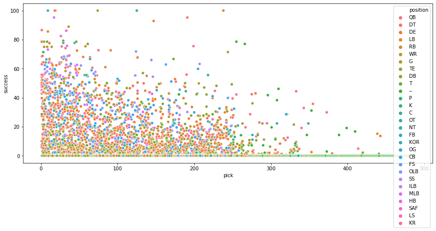

```python
plt.figure(figsize=(15, 6))
sns.scatterplot(data=draft, x='pick', y='success', hue='position')
```

We also dropped the values that were 0 since some players were missing statistical data

```python
draftdrop = draft
draftdrop['nan'] = draftdrop.apply(lambda x: x['success']!=0, axis=1)
draftdrop = draftdrop[draftdrop.nan]
```

```python
regdrop = linear_model.LinearRegression()
pickdrop = np.array([[y] for y in draftdrop['pick']])
rounddrop = np.array([[y] for y in draftdrop['round']])
successdrop = draftdrop['success'].tolist()
```

```python
reg.fit(pickdrop, successdrop)
reg.predict([[1]])
```

```
array([25.4754696])
```

## Graph for Data without 0's

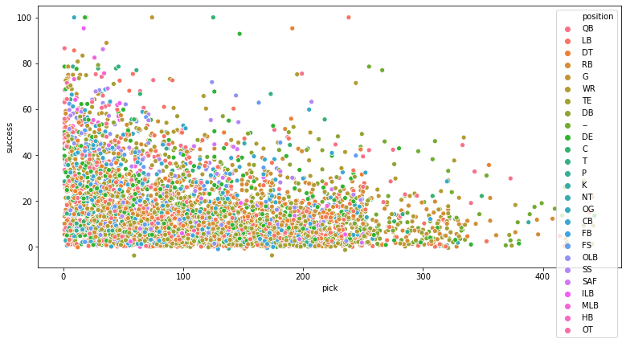

```python
plt.figure(figsize=(13, 6))
sns.scatterplot(data=draftdrop, x='pick', y='success', hue='position')
```

## Regression based on position

Since not every position is created equal we decided to perform linear regression based on the draft number and player position.

```python
positions = {}
for i, row in draftdrop.iterrows():
    if row['position'] not in positions:
        positions[row['position']] = 1
positions.keys()
```

```
dict_keys(['QB', 'LB', 'DT', 'RB', 'G', 'WR', 'TE', 'DB', '--', 'DE', 'C', 'T', 'P', 'K', 'NT', 'OG', 'CB', 'FB', 'FS', 'OLB', 'SS', 'SAF', 'ILB', 'MLB', 'HB', 'OT'])
```

```python
for i in positions.keys():
    draftdrop[i] = draftdrop.apply(lambda x: 1 if x['position']==i else 0, axis=1)
```

```python
reg2 = sm.ols(formula='success ~ pick + QB + LB + DT + RB + G + WR + TE + DE + DB + C + T + P + K + NT + OG + CB + FB + FS + OLB + SS + SAF + ILB + MLB + HB + OT + (QB:pick) + (LB:pick) + (DT:pick) + (RB:pick) + (G:pick) + (WR:pick) + (TE:pick) + (DE:pick) + (DB:pick) + (C:pick) + (T:pick) + (P:pick) + (K:pick) + (NT:pick) + (OG:pick) + (CB:pick) + (FB:pick) + (FS:pick) + (OLB:pick) + (SS:pick) + (SAF:pick) + (ILB:pick) + (MLB:pick) + (HB:pick) + (OT:pick)', data=draftdrop)
```

```python
model = reg2.fit()
model.params
```

```
Intercept    17.674392
pick         -0.012730
QB           17.041980
LB            3.001025
DT            3.345150
RB            4.795868
G            22.658612
WR            9.744150
TE            1.170966
DE            4.579330
DB            1.658053
C            17.262944
T             7.635058
P           -12.866157
K           -15.200439
NT           -3.029153
OG           47.356054
CB           13.367296
FB           -2.472051
FS           13.477735
OLB          19.819584
SS           30.717456
SAF          24.042064
ILB          38.767642
MLB          39.091601
HB            0.015440
OT           45.807159
QB:pick      -0.051596
LB:pick      -0.040437
DT:pick      -0.031930
RB:pick      -0.033643
G:pick       -0.098670
WR:pick      -0.054447
TE:pick      -0.044093
DE:pick      -0.037598
DB:pick      -0.028572
C:pick       -0.027665
T:pick       -0.031306
P:pick        0.003399
K:pick        0.036655
NT:pick      -0.026987
OG:pick      -0.209543
CB:pick      -0.067743
FB:pick      -0.026932
FS:pick      -0.022891
OLB:pick     -0.103613
SS:pick      -0.116142
SAF:pick     -0.130342
ILB:pick     -0.267157
MLB:pick     -0.247457
HB:pick       0.663905
OT:pick      -0.531263
dtype: float64
```

```python
TomB = pd.DataFrame({'pick':[199], 'position':['QB']})
for i in positions.keys():
    TomB[i] = TomB.apply(lambda x: 1 if x['position']==i else 0, axis=1)
model.predict(TomB)
```

```
0    21.915599
dtype: float64
```

We decided to test our regression on arguable the best Quarterback to every play, Tom Brady, he was drafted extremely low considering how good he ended up being. He was drafted 199th overall and our regression model says that he should have a score of 21.9 which is much lower than his actual score of 75.5.

```python
residuals = pd.DataFrame()
residuals['pick'] = draftdrop['pick']
residuals['predict'] = model.predict(draftdrop)
residuals['success'] = draftdrop['success']
residuals['residual'] = residuals.apply(lambda x: x['success']-x['predict'], axis=1)
residuals['position'] = draftdrop['position']
```

## Graph of Residuals

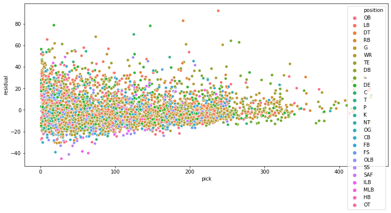

```python
plt.figure(figsize=(13,6))
sns.scatterplot(x='pick', y='residual', data=residuals, hue='position')
```

Our model will predict a players success based on their draft number and position. The value predicted is far from perfect but we have shown that on average players drafted earlier in the draft are better than ones drafted later. Excluding a few outliers such as Tom Brady who has outperformed almost everyones expectations. looking at the residuals a player is more likely to be much more succesful than predicted while it is far less likely for them be less successful. This is likely due to the fact that players drafted often never play at a high level in the nfl causing our model to show low averages. many players play a few games before being cut from a team or released due to injury.